# Getting Started with R

[STOR 390](https://idc9.github.io/stor390/)

January 12, 2017

# Stuff to install

## R

**Download the latest version of R from the [Comprehensive R Archive Network](https://cran.rstudio.com/)** (CRAN). [R](https://www.r-project.org/about.html) is a programming language built for statistical analysis.

## R Studio

**Download [R Studio](https://www.rstudio.com/products/rstudio/#Desktop)** which is an [IDE](https://en.wikipedia.org/wiki/Integrated_development_environment) built for R. While you can use R without R Studio, R Studio makes life much better.

Watch the [video on this page](https://www.rstudio.com/products/RStudio/) for the basics parts of R Studio

## Updating R/R Studio

If you already have R and R Studio please update both of them. For instructions see [this page](http://bioinfo.umassmed.edu/bootstrappers/bootstrappers-courses/courses/rCourse/Additional_Resources/Updating_R.html).

# Basic R commands

You downloaded [base R](https://www.rstudio.com/wp-content/uploads/2016/05/base-r.pdf) from CRAN.

Run the following in your R console

```r
1 + 1
```

```
## [1] 2
```

```r
a <- 1
b <- 2
a + b
```

```
## [1] 3
```

If you are new to R I suggest reading through [before we start](http://www.datacarpentry.org/R-ecology-lesson/00-before-we-start.html) and [intro to R](http://www.datacarpentry.org/R-ecology-lesson/01-intro-to-R.html).

# Packages

The power of R comes from the many wonderful R packages people develop. R is an [open source](https://en.wikipedia.org/wiki/Open-source_software) language meaning anyone can develop a new R package.

You can install a package from [CRAN](https://cran.r-project.org/) like this

```r
install.packages("tidyverse")
```

There are other sources of R packages such as [Bioconductor](http://www.bioconductor.org/) and [Github](https://github.com/). Packages from CRAN and Bioconductor are vetted (though not perfectly). Packages on Github are not.

To use code from an R package you need to load it

```r
# ignore the warnings for now
library(tidyverse)
```

You need to load an R package every time you want to use it. You only need to install it once.

# IMBD

Load the [movies data set](http://www2.stat.duke.edu/~mc301/data/movies.html) generously curated by [Mine Cetinkaya-Rundel](http://www2.stat.duke.edu/~mc301/)

```r
# downloads data set and loads it into R
load(url('https://stat.duke.edu/~mc301/data/movies.Rdata'))
```

The first thing you should do when you get a data set is [look at it](https://www.youtube.com/watch?v=EF8GhC-T_Mo)!

## Numerical summaries

`str()` tells you about the data frame. First thing to note is the dimension of the data frame (651 rows by 32 columns)and the column types

```r
str(movies)
```

```
## Classes 'tbl_df', 'tbl' and 'data.frame':    651 obs. of  32 variables:
##  $ title           : chr  "Filly Brown" "The Dish" "Waiting for Guffman" "The Age of Innocence" ...
##  $ title_type      : Factor w/ 3 levels "Documentary",..: 2 2 2 2 2 1 2 2 1 2 ...
##  $ genre           : Factor w/ 11 levels "Action & Adventure",..: 6 6 4 6 7 5 6 6 5 6 ...
##  $ runtime         : num  80 101 84 139 90 78 142 93 88 119 ...
##  $ mpaa_rating     : Factor w/ 6 levels "G","NC-17","PG",..: 5 4 5 3 5 6 4 5 6 6 ...
##  $ studio          : Factor w/ 211 levels "20th Century Fox",..: 91 202 167 34 13 163 147 118 88 84 ...
##  $ thtr_rel_year   : num  2013 2001 1996 1993 2004 ...
##  $ thtr_rel_month  : num  4 3 8 10 9 1 1 11 9 3 ...
##  $ thtr_rel_day    : num  19 14 21 1 10 15 1 8 7 2 ...
##  $ dvd_rel_year    : num  2013 2001 2001 2001 2005 ...
##  $ dvd_rel_month   : num  7 8 8 11 4 4 2 3 1 8 ...
##  $ dvd_rel_day     : num  30 28 21 6 19 20 18 2 21 14 ...
##  $ imdb_rating     : num  5.5 7.3 7.6 7.2 5.1 7.8 7.2 5.5 7.5 6.6 ...
##  $ imdb_num_votes  : int  899 12285 22381 35096 2386 333 5016 2272 880 12496 ...
```

[output cut: 18 more lines]

`head()` prints the first six rows of a data set (and as many columns that will fit on the screen)

```r
head(movies)
```

```
## # A tibble: 6 × 32
##                  title   title_type       genre runtime mpaa_rating
##                  <chr>       <fctr>      <fctr>   <dbl>      <fctr>
## 1          Filly Brown Feature Film       Drama      80           R
## 2             The Dish Feature Film       Drama     101       PG-13
## 3  Waiting for Guffman Feature Film      Comedy      84           R
## 4 The Age of Innocence Feature Film       Drama     139          PG
## 5          Malevolence Feature Film      Horror      90           R
## 6          Old Partner  Documentary Documentary      78     Unrated
## # ... with 27 more variables: studio <fctr>, thtr_rel_year <dbl>,
## #   thtr_rel_month <dbl>, thtr_rel_day <dbl>, dvd_rel_year <dbl>,
## #   dvd_rel_month <dbl>, dvd_rel_day <dbl>, imdb_rating <dbl>,
## #   imdb_num_votes <int>, critics_rating <fctr>, critics_score <dbl>,
## #   audience_rating <fctr>, audience_score <dbl>, best_pic_nom <fctr>,
## #   best_pic_win <fctr>, best_actor_win <fctr>, best_actress_win <fctr>,
## #   best_dir_win <fctr>, top200_box <fctr>, director <chr>, actor1 <chr>,
## #   actor2 <chr>, actor3 <chr>, actor4 <chr>, actor5 <chr>,
## #   imdb_url <chr>, rt_url <chr>
```

If you double click a data frame it will pull up R’s built in spreadsheet

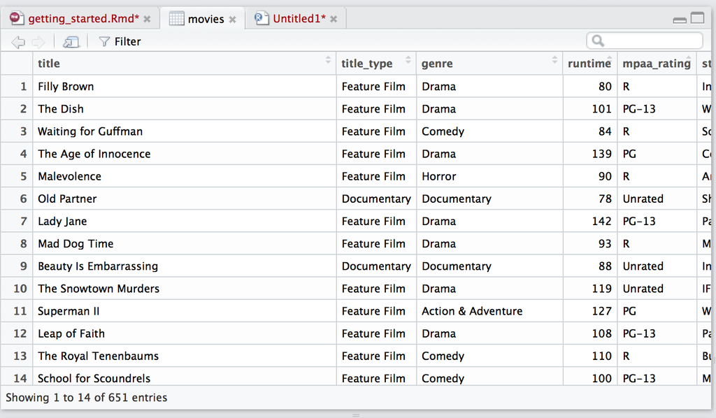

`summary()` prints out some descriptive statistics of each column

```r
summary(movies)
```

```
##     title                  title_type                 genre
##  Length:651         Documentary : 55   Drama             :305
##  Class :character   Feature Film:591   Comedy            : 87
##  Mode  :character   TV Movie    :  5   Action & Adventure: 65
##                                        Mystery & Suspense: 59
##                                        Documentary       : 52
##                                        Horror            : 23
##                                        (Other)           : 60
##     runtime       mpaa_rating                               studio
##  Min.   : 39.0   G      : 19   Paramount Pictures              : 37
##  1st Qu.: 92.0   NC-17  :  2   Warner Bros. Pictures           : 30
##  Median :103.0   PG     :118   Sony Pictures Home Entertainment: 27
##  Mean   :105.8   PG-13  :133   Universal Pictures              : 23
##  3rd Qu.:115.8   R      :329   Warner Home Video               : 19
##  Max.   :267.0   Unrated: 50   (Other)                         :507
##  NA's   :1                     NA's                            :  8
##  thtr_rel_year  thtr_rel_month   thtr_rel_day    dvd_rel_year
##  Min.   :1970   Min.   : 1.00   Min.   : 1.00   Min.   :1991
##  1st Qu.:1990   1st Qu.: 4.00   1st Qu.: 7.00   1st Qu.:2001
##  Median :2000   Median : 7.00   Median :15.00   Median :2004
##  Mean   :1998   Mean   : 6.74   Mean   :14.42   Mean   :2004
##  3rd Qu.:2007   3rd Qu.:10.00   3rd Qu.:21.00   3rd Qu.:2008
##  Max.   :2014   Max.   :12.00   Max.   :31.00   Max.   :2015
##                                                 NA's   :8
##  dvd_rel_month     dvd_rel_day     imdb_rating    imdb_num_votes
##  Min.   : 1.000   Min.   : 1.00   Min.   :1.900   Min.   :   180
##  1st Qu.: 3.000   1st Qu.: 7.00   1st Qu.:5.900   1st Qu.:  4546
##  Median : 6.000   Median :15.00   Median :6.600   Median : 15116
##  Mean   : 6.333   Mean   :15.01   Mean   :6.493   Mean   : 57533
##  3rd Qu.: 9.000   3rd Qu.:23.00   3rd Qu.:7.300   3rd Qu.: 58300
##  Max.   :12.000   Max.   :31.00   Max.   :9.000   Max.   :893008
##  NA's   :8        NA's   :8
##          critics_rating critics_score    audience_rating audience_score
##  Certified Fresh:135    Min.   :  1.00   Spilled:275     Min.   :11.00
##  Fresh          :209    1st Qu.: 33.00   Upright:376     1st Qu.:46.00
##  Rotten         :307    Median : 61.00                   Median :65.00
##                         Mean   : 57.69                   Mean   :62.36
##                         3rd Qu.: 83.00                   3rd Qu.:80.00
##                         Max.   :100.00                   Max.   :97.00
##
```

[output cut: 17 more lines]

```
##  Length:651         Length:651         Length:651
##  Class :character   Class :character   Class :character
##  Mode  :character   Mode  :character   Mode  :character
##
##
##
##
##    imdb_url            rt_url
##  Length:651         Length:651
##  Class :character   Class :character
##  Mode  :character   Mode  :character
##
##
##
##
```

The `$` sign after a data frame will return a column

```r
movies$imdb_num_votes
```

```
##   [1]    899  12285  22381  35096   2386    333   5016   2272    880  12496
##  [11]  71979   9669 201779  25808   5544 240033  66489   6336  37769  21268
##  [21]  56201   3459  16717   9357   4541   1816 163490  19285   3688   3488
##  [31]  82851  56128  33101 259822   4908 290356  47297   2145 466400  69338
##  [41]   6228  75468  48519  13523  58668   9654  22079   5258    761  33839
##  [51]    183 225130  62241  19714 137126  10468  37770   1628   5587   6247
##  [61]   8646   8320   2362   1942 110238  21501  14359  12450  21704   4375
##  [71]  48324   4768   2944   6788  24783   3745  54726   1493   5616  10492
##  [81]   4451  12269  60335   5035 315051  82737   4944   8229   4516   7858
##  [91]  10938 279704  11192   3851   1838   6552    390  68429 182983   1147
## [101]  35635   2569  13980  11477   9853  14970   9001  35868  41767   6954
## [111] 893008   3467 117688   2817  32751   5704    318 123989  70209    541
## [121] 132215 127458  27769  52635  12819   6054   9367  17798  26010   4515
## [131]    535  71572  57933   1784   3883   2282 105745 104457 205065 562136
## [141]   1778   7628  17934   2502  13092   1010   4687  48137 164112  30921
```

[output cut: 51 more lines]

The `mean()` function computes the mean of a vector. There is also a `median`, `var`, `min`, `max`

```r
mean(movies$imdb_num_votes)
```

```
## [1] 57532.98
```

## Vizualization

You can only learn so much by looking lists of numbers. Let’s make some plots.

There are two popular plotting systems in R. There is the *base* R system

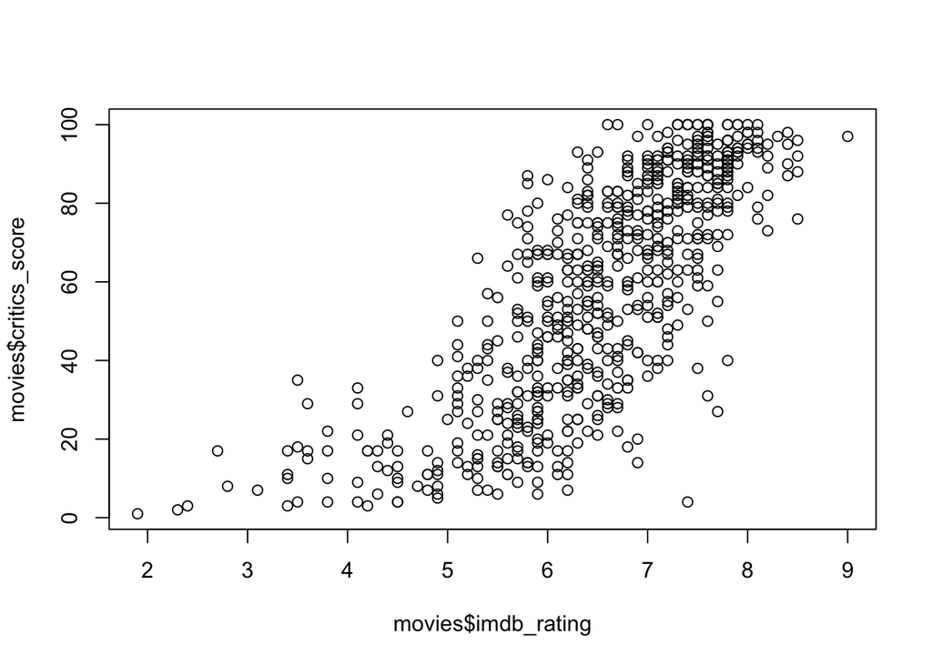

```r
plot(movies$imdb_rating, movies$critics_score)
```

and [ggplot2](http://ggplot2.org/).

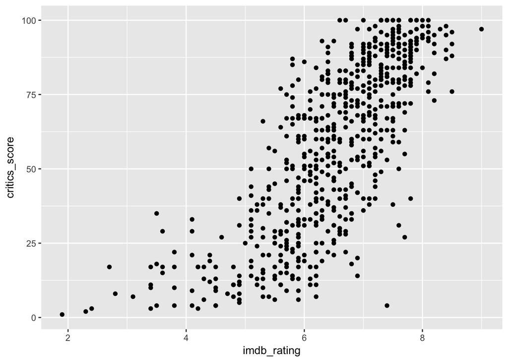

```r
# ggplot was loaded with tidyverse
ggplot(data = movies) + geom_point(mapping = aes(x = imdb_rating, y = critics_score))
```

We will use ggplot2 in this course (see readings below about ggplot2 vs base). ggplot2 can be a bit intimidating at first – especially if you are used to base plotting.

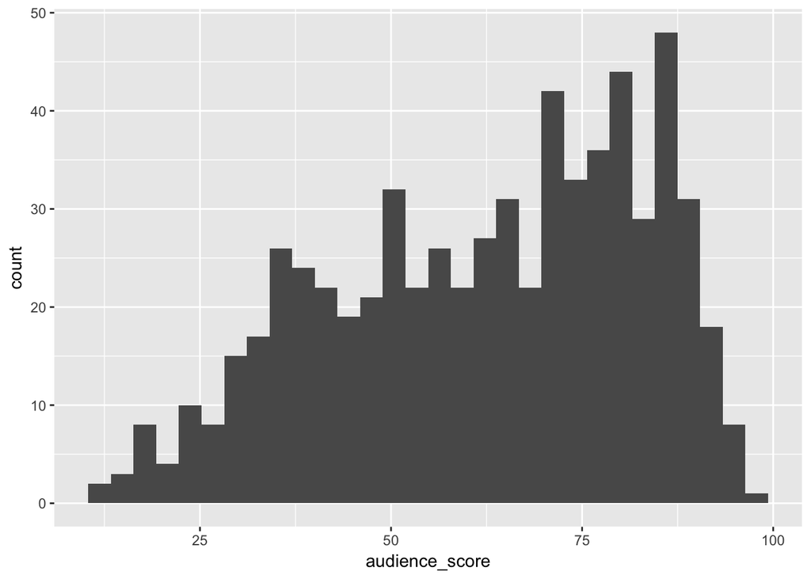

```r
ggplot(data=movies, aes(x=audience_score)) + geom_histogram()
```

ggplot2 has a ton of functionality built it and you will learn to love it when you get used to it.

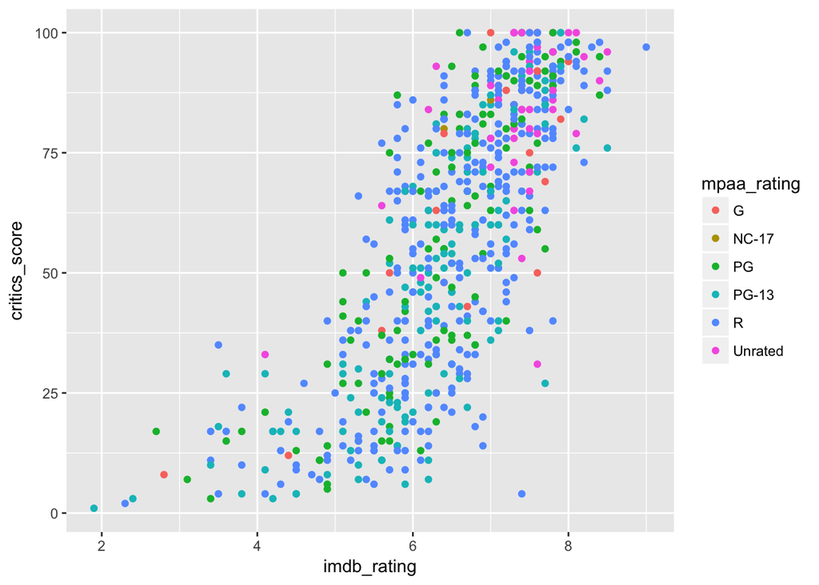

```r
ggplot(data = movies) + geom_point(mapping = aes(x = imdb_rating, y = critics_score, color=mpaa_rating))
```

# Getting help

The main textbook for this class is [R for Data Science](http://r4ds.had.co.nz/data-visualisation.html) written by Hadley Wickham (it’s free online). I have put up a [long list of alternative resources](https://idc9.github.io/stor390/course_info/references.html) (textbooks, coursera courses, etc).

Google and [StackOverflow](http://stackoverflow.com/) will become your best friends. If you have a question, chances are someone has already asked and answered it. If R gives you an error message you don’t understand google it – someone else has probably figured it out and posted it online.

The course staff is of course here to help you. If you get stuck on something **spend at least 5 minutes Googling/hacking at it**. There is a good chance the first thing one of us will do is turn to google. **Don’t spend more than 20 minutes stuck on one thing** – at this point you should as for help.

# [Yak Shaving](https://en.wiktionary.org/wiki/yak_shaving)

> Any apparently useless activity which, by allowing you to overcome intermediate difficulties, allows you to solve a larger problem.

*I was doing a bit of yak shaving this morning, and it looks like it might have paid off.*

Programming/data science requires a lot of yak shaving which can be quite frustrating. You will probably come across the following quote at some point

> 80 percent of data science is data cleaning

# Literate programming and R Markdown

[Literate Programming](https://en.wikipedia.org/wiki/Literate_programming) is a concept introduced by Donald Knuth saying you should *write code that communicates primarily to hummans, not computers*. Here are some examples:

- [Jane Austen and R](https://cran.r-project.org/web/packages/tidytext/vignettes/tidytext.html)
- [Document Clustering with Python](http://brandonrose.org/clustering)

[R Markdown](http://rmarkdown.rstudio.com/) allows you easily write documents that contain: R code, text, images, links, etc. It may sounds bland at first R Markdown [is pretty amazing](http://rmarkdown.rstudio.com/gallery.html). The lecture notes and course webpage were done with R Markdown.

Open a new R Markdown document and play around with it. We will use R Markdown quite a bit in the class. You can read more [about R Markdown in r4ds](http://r4ds.had.co.nz/r-markdown.html#r-markdown-basics). This document may be helpful to get started with R Markdown: http://stat545.com/block007_first-use-rmarkdown.html

If you are using Python then you’ll find [Jupyter notebooks](http://jupyter.org/) are the best thing since sliced bread (there are now [R notebooks](http://rmarkdown.rstudio.com/r_notebooks.html)) .

# Additional references

- ggplot2 vs. base plotting
  - [Why I don’t use ggplot2](http://simplystatistics.org/2016/02/11/why-i-dont-use-ggplot2/)
  - [Why I use ggplot2](http://varianceexplained.org/r/why-I-use-ggplot2/)
- [R vs. Python](https://www.datacamp.com/community/tutorials/r-or-python-for-data-analysis#gs.wZYq5Q8)
  - “better to be good at one then mediocre at first” (I’ve heard this from multiple sources but can’t seem to find a link to one…)
  - a priori doesn’t matter – there are cases when one is better than the other